# RESOLUCIÓN DEL EXAMEN PARCIAL

GRUPO 4

5/8/2021

| Integrante | Código |
| --- | --- |
| Chavez Chipana Joel Jorge | 17160041 |
| Coba Bautista Kevin | 17160042 |
| Conislla Huamanyalli Rocio del Pilar | 17160181 |
| Silvestre Jimenez Brenda Pamela | 17160045 |
| Tuanama Satalaya Pierina Isabel | 17160054 |

## INDICE

**PARTE 1**

**PARTE 2**

**PARTE 3**

## PARTE 1

1. Se tiene una variable x (no necesariamente temperatura) que depende de la elevación. Se sabe que entre los 1000 y 3000 metros, esta variable se ve reducido en 2 unidades cada 500 metros. Entre los 3000 y 4000 metros, varía en 0.5 unidades, y a una altitud mayor, su valor es constante. Cree una función que permita obtener el valor de esta variable, únicamente con el dato de la elevación.
- El valor de la variable x a 1000 metros es de 81.4 unidades.

Solución:

```r
funcion <- function(h, x = 81.4){
  if (h == 1000){
    var1 = 81.4
    return(var1)
  } else if (h<=3000 & h> 1000){
    var1 = x - 2*((h-1000)%/%500)
    return(var1)
  } else if (h > 3000 & h<=4000){
    var1 = x - 8 - 0.5*((h-3000)%/%500)
    return(var1)
  } else if (h > 4000){
    var1 = x - 9
    return(var1)
  } else {
    print("error!")
  }
}

funcion(1000)
```

```
## [1] 81.4
```

```r
funcion(1500)
```

```
## [1] 79.4
```

```r
funcion(5000)
```

```
## [1] 72.4
```

```r
funcion(999)
```

```
## [1] "error!"
```

2. Resolver el siguiente sistema de ecuaciones.

$$3a+2b-2c=0\\
2a-1b+3c=9\\
a+4b+2c=-4$$

Solución:

```r
k <- matrix(c(3,2,1,2,-1,4,-2,3,2), ncol=3, nrow=3)
l <- c(0,9,-4)
solve(k,l)
```

```
## [1]  2 -2  1
```

## PARTE 2

1. A partir de los datos adjuntos, se solicita lo siguiente:
1. Calcular la precipitación acumulada anual (Valores observados) para la cuenca asignada.

Solución:

```r
# Primero debemos cargar la data a trabajar
data1 <- as_tibble(read.csv("mods_clima_uh.csv"))

ppacmu <- data1 %>% dplyr::select(uh_name, bh_month , bh_pc , bh_esc) %>%
  dplyr::filter(uh_name == "Cuenca Tumbes" , bh_esc == "Observado")%>%
  summarise(ppacum = sum(bh_pc, na.rm = T))
ppacmu
```

```
## # A tibble: 1 x 1
##   ppacum
##    <dbl>
## 1   852.
```

2. Calcular el porcentaje de sesgo (% PBIAS) de los escenarios climàticos(ACCESS, HADGEM2 , MPI) respecto a los datos observados para cada mes ( enero- diciembre) de cada variable, para la cuenca asignada.

Solución:

```r
data2 <- data1 %>% dplyr::select(uh_name, bh_month , bh_pc , bh_esc) %>%
  dplyr::filter(uh_name == "Cuenca Tumbes") %>%
  pivot_wider(names_from = "bh_esc", values_from = "bh_pc")
library(hydroGOF)
(OB_ACCES <-pbias(data2$`ACCESS 1.0` , data2$Observado , na.rm = T))
```

```
## [1] 25.9
```

```r
(OB_HadGE <-pbias(data2$`HadGEM2-ES` , data2$Observado , na.rm = T))
```

```
## [1] 13.8
```

```r
(OB_MPIEM <-pbias(data2$`MPI-ESM-LR` , data2$Observado , na.rm = T))
```

```
## [1] -1.5
```

3. De la pregunta anterior, ¿Cuál es el escenario climático más preciso? Fundamente su respuesta.

Solución:

- El modelo mejor estiamdo es el MPI-ESM-LR ya que tiene un valor cercano a 0 que es el optimo pero su valor negativo nos indica una subestimacion del modelo.
4. Graficar, con ggplot2, la precipitación (enero a diciembre) observada y modelos climáticos.

Solución:

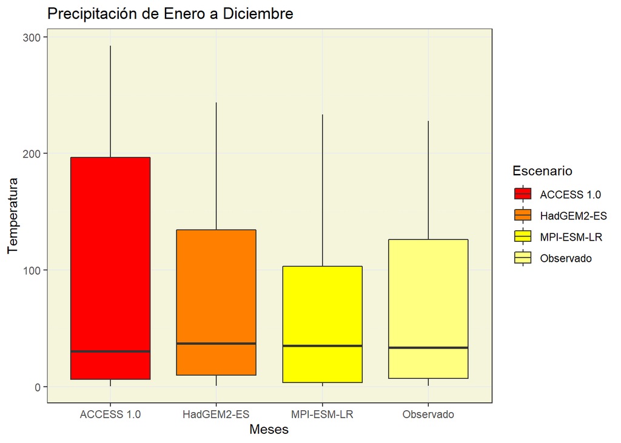

```r
cuenca <- data1 %>% dplyr::select(uh_name, bh_month , bh_pc , bh_esc) %>%
  dplyr::filter(uh_name == "Cuenca Tumbes")%>%
  rename(Cuenca = uh_name , month = bh_month , pp = bh_pc, Escenario = bh_esc)

#Gráfico con boxplot
ggplot(data = cuenca ,mapping = aes(x = Escenario, y = pp, fill = Escenario)) +
  geom_boxplot()+
  labs(title = "Precipitación de Enero a Diciembre",  x = "Escenarios",  y = "Precipitación")+
  scale_fill_manual(values=heat.colors(4))+
  theme_bw() +
  theme(
    panel.background = element_rect(fill = "beige"),
    panel.grid.minor = element_line(linetype = "dotted")
  )+
  labs(x= "Meses", y ="Temperatura")
```

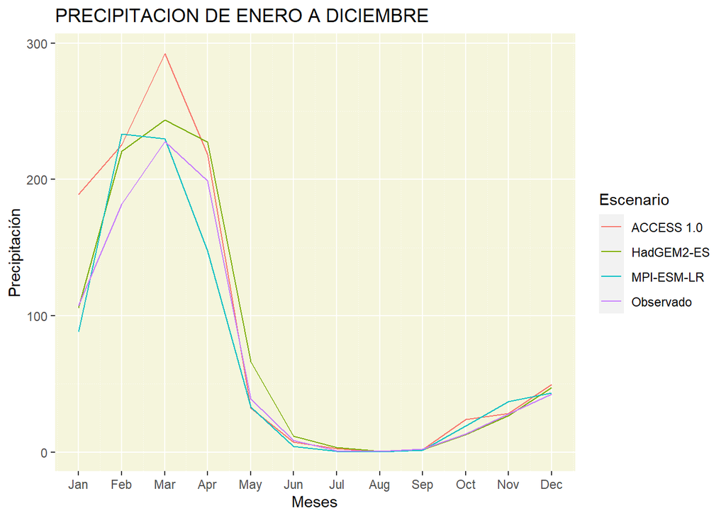

```r
#Gráfico con lineas y puntos
ggplot(cuenca,
       mapping = aes(x = month,
                     y = pp,
                     color = Escenario))+
  geom_line()+
  scale_x_continuous(
    breaks = c(1:12),
    labels = month.abb,
  )+
  theme(
    panel.background = element_rect(fill = "beige"),
    panel.grid.minor = element_line(linetype = "dotted")
  )+
  ggtitle("PRECIPITACION DE ENERO A DICIEMBRE")+
  labs(x = "Meses",
       y = "Precipitación")
```

## PARTE 3

1. Se tiene el conjunto de datos de temperatura diaria (período 1928 - 2015) de ciertas estaciones meteorológicas (temperatureDataset.csv), donde cada una de estas están asociadas a un código único (p.e. qc00000208). Si existen valores iguales a -99.9, considerarlos como missing values y convertirlos a NA.

1.a. Determine la cantidad de missing values para los años hidrológicos Sep1983-Agos1984 y Sep1997-Agos1998.

Solución:

```r
#Cargamos el dataset de temperatura
data3 <- as_tibble(read.csv("temperatureDataset.csv", na.strings = -99.9))

data4 <- data3 %>% select(DATE, qc00000805)%>%
  mutate(DATE = as.Date(DATE, format = "%d/%m/%Y"))%>%
  rename(temp = qc00000805)%>%
  arrange(DATE)

data4 %>% dplyr::filter(DATE >="1983-09-01" , DATE <="1984-08-31" |DATE >="1997-09-01" , DATE <="1997-09-01") %>%
  summarise( miss_invalue =sum(is.na(temp)))
```

```
## # A tibble: 1 x 1
##   miss_invalue
##          <int>
## 1            1
```

1.b. Calcule la serie de tiempo de temperatura mensual (si el de días con missing values, en un mes, supera el 5%, la temperatura mensual sería considerado como un NA). Además, identifique, visualmente, posibles valores atípicos y describa una posible causa.

Solución:

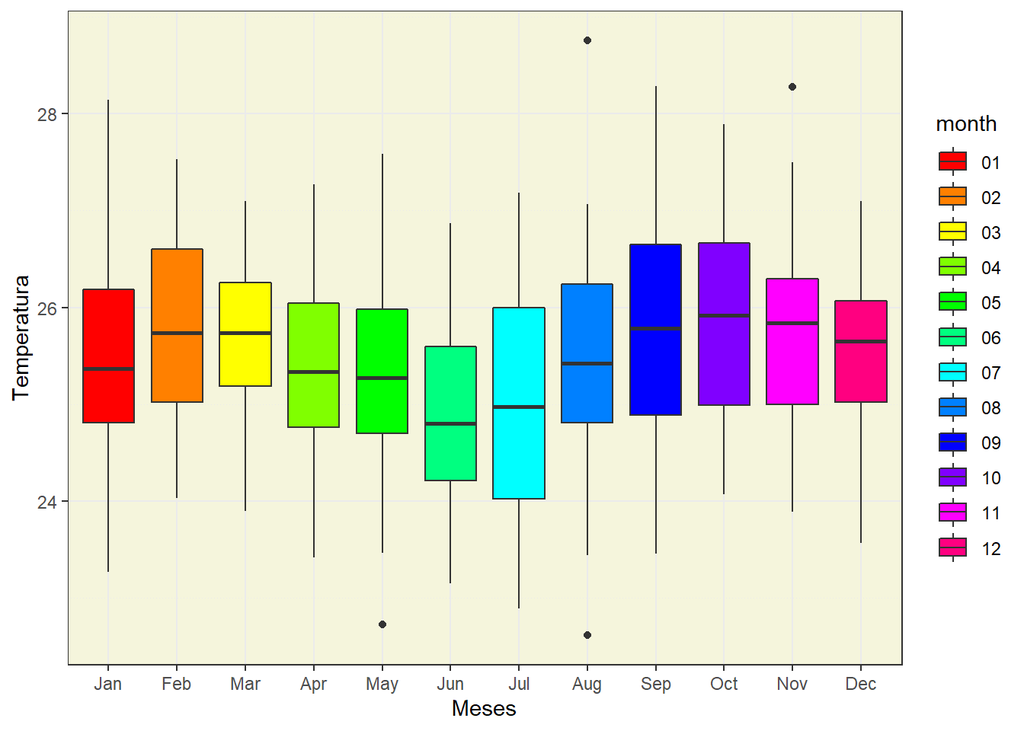

```r
data6 <- data4 %>%
  group_by(DATE = str_sub(DATE, 1, 7)) %>%
  mutate(MissVal = sum(is.na(temp))*100/n()) %>%
  summarise(
    temp = mean(temp, na.rm = T),
    MissVal = unique(MissVal)
  ) %>%
  mutate(
    temp = ifelse(MissVal >=5, NA, temp),
    DATE = as.Date(sprintf("%1$s-01", DATE)),
    month = str_sub(DATE, 6, 7)
  )
ggplot(data = data6, mapping = aes(x = month, y = temp, fill = month)) +
  geom_boxplot()+
  scale_fill_manual(values=rainbow(12))+
  theme_bw() +
  theme(
    panel.background = element_rect(fill = "beige"),
    panel.grid.minor = element_line(linetype = "dotted")
  )+
  scale_x_discrete(
    labels = month.abb,
  )+
  labs(x= "Meses", y ="Temperatura")
```

1.c. Determine la cantidad de missing values de la serie de tiempo a paso mensual para los años 2005 y 2010.

Solución:

```r
(data5 <- data4 %>%
  group_by(DATE = str_sub(DATE, 1, 7)) %>%
  mutate(MissVal = sum(is.na(temp))) %>%
  summarise(
    temp = mean(temp, na.rm = T),
    MissVal = unique(MissVal)
  ) %>%
  dplyr::filter(DATE >= "2005-01-01" & DATE < "2005-12-31" |
                  DATE >= "2010-01-01" & DATE < "2010-12-31") %>%
  mutate(
    DATE = as.Date(sprintf("%1$s-01", DATE)),
    month = str_sub(DATE, 6, 7)
  ))
```

```
## # A tibble: 22 x 4
##    DATE        temp MissVal month
##    <date>     <dbl>   <int> <chr>
##  1 2005-02-01  25.0       0 02
##  2 2005-03-01  24.8       0 03
##  3 2005-04-01  24.5       0 04
##  4 2005-05-01  24.5       0 05
##  5 2005-06-01  24.8       0 06
##  6 2005-07-01  23.7       0 07
##  7 2005-08-01  25.1       0 08
##  8 2005-09-01  24.5       0 09
##  9 2005-10-01  24.4       0 10
## 10 2005-11-01  24.8       0 11
## # ... with 12 more rows
```

1.d. Cree una función que calcule, a partir de los datos de temperatura mensual, la climatología (Ene-Dic). Obtener la climatología para los períodos 1980-1995 y 1996-2010. Plotear sus resultados en una sola gráfica para describir sus diferencias y/o similitudes (entre climatologías).

Solución:

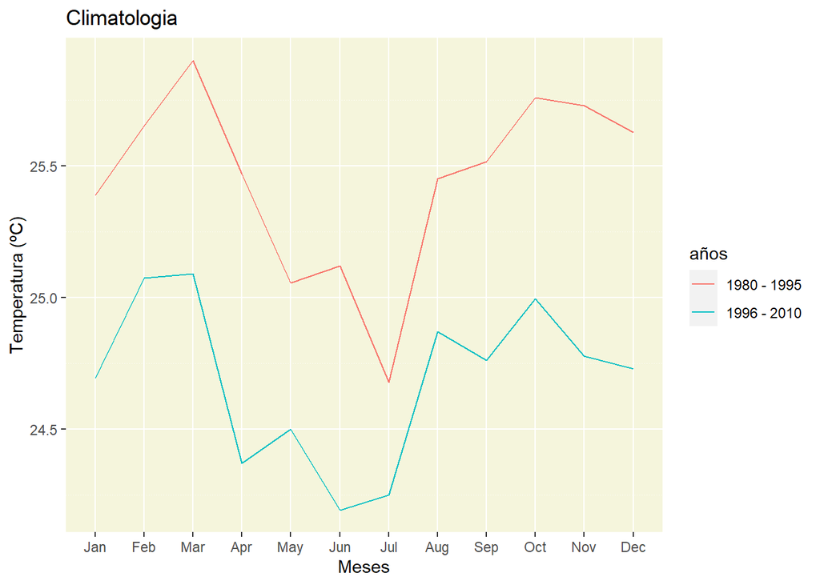

```r
prueba1 <- function(data,year1,year2){
  data %>% mutate( año= as.integer(str_sub(DATE, 1,4))) %>%
    dplyr::filter(año %in% year1:year2) %>%
    group_by(month) %>%
    summarise(tempmean =mean(temp,na.rm = T)) %>%
    mutate(años = sprintf( "%1s - %1s" , year1 , year2))
  }

pur <-prueba1(data6,1980,1995)
par <-prueba1(data6,1996,2010)
ejer_f <-rbind(pur,par)

ggplot(ejer_f,
       mapping = aes(x = month,
                     y = tempmean,
                     group=años,
                     color= años))+
  geom_line()+
  scale_x_discrete(
    labels = month.abb,
  )+
  theme(
    panel.background = element_rect(fill = "beige"),
    panel.grid.minor = element_line(linetype = "dotted")
  )+
  ggtitle("Climatologia")+
  labs(x = "Meses",
       y = "Temperatura (ºC)")
```

1.e. Plotear (boxplot) la variabilidad de los valores mensuales (Ene-Dic) para el período 1980-2013 y describirlo correctamente.

Solución

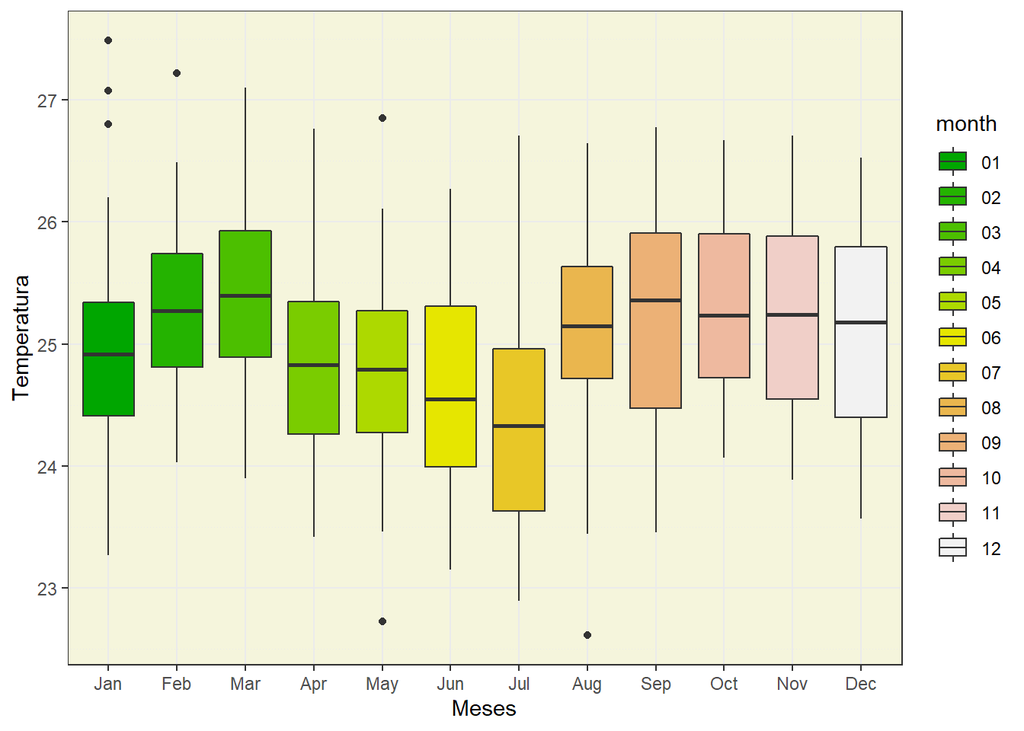

```r
data6 %>%
  dplyr::filter(DATE >="1980-01-01" & DATE <="2013-12-31") %>%
  ggplot(mapping = aes(x =month, y= temp, fill=month))+
  geom_boxplot()+
  scale_fill_manual(values=terrain.colors(12))+
  theme_bw() +
  theme(
    panel.background = element_rect(fill = "beige"),
    panel.grid.minor = element_line(linetype = "dotted")
  )+
  scale_x_discrete(
    labels = month.abb,
  )+
  labs(x= "Meses", y ="Temperatura")
```